# Notebook

**Step 1: Data Loading and Initial Processing**

The dataset, zillow_combined_zhvi.csv, was carefully loaded and initially explored. It contains extensive information about various geographic and economic factors influencing home values, including latitude, longitude, income growth, population changes, and historical home prices. Early preprocessing addressed critical missing data issues effectively by applying mean imputation for predictor variables, preserving data integrity without significantly distorting feature distributions.

```python
import pandas as pd
data = pd.read_csv('zillow_combined_zhvi.csv')
```

```python
from sklearn.impute import SimpleImputer
imputer = SimpleImputer(strategy='mean')
X_imputed = pd.DataFrame(imputer.fit_transform(X), columns=features)
```

**Step 2: Data Splitting & Handling Missing Values**

Crucially, rows containing missing values in the target variable (AnnualValue_AllHomes) were identified and removed to ensure accurate and reliable model training and validation. The dataset was then divided into training and test sets using an 80%-20% split, providing a balanced evaluation of the model’s predictive performance and its ability to generalize to unseen data.

```python
from sklearn.model_selection import train_test_split
X_train, X_test, y_train, y_test = train_test_split(X_imputed, y, test_size=0.2, random_state=42)
```

```python
# Remove rows where target (y) is NaN
valid_indices = y.notna()

X_valid = X_imputed[valid_indices]
y_valid = y[valid_indices]
```

```python
from sklearn.model_selection import train_test_split

X_train, X_test, y_train, y_test = train_test_split(
    X_valid, y_valid, test_size=0.2, random_state=42
)
```

**Step 3: Model Development and Evaluation**

Multiple sophisticated regression models, including Linear Regression, Random Forest, XGBoost, Gradient Boosting, and Support Vector Regression (SVR), were systematically trained and evaluated. Hyperparameter tuning using GridSearchCV was performed comprehensively for ensemble models, significantly enhancing predictive performance. The Random Forest model, after tuning, notably achieved a remarkably high R² score (~0.9955), signifying its superior ability to predict Zillow home values with minimal error.

```python
from sklearn.model_selection import GridSearchCV
from sklearn.ensemble import RandomForestRegressor

param_grid_rf = {
    'n_estimators': [100, 200],
    'max_depth': [None, 10, 20],
    'min_samples_split': [2, 5]
}

grid_search_rf = GridSearchCV(
    estimator=RandomForestRegressor(random_state=42),
    param_grid=param_grid_rf,
    scoring='r2',
    cv=5,
    n_jobs=-1
)

grid_search_rf.fit(X_train, y_train)

# Best hyperparameters and their corresponding R² score
print("Best parameters found:", grid_search_rf.best_params_)
print("Best cross-validation R² score:", grid_search_rf.best_score_)
```

```
Best parameters found: {'max_depth': None, 'min_samples_split': 2, 'n_estimators': 100}
Best cross-validation R² score: 0.9910341545376005
```

```python
from sklearn.metrics import r2_score, mean_squared_error, mean_absolute_error
import numpy as np

# Predict with the best estimator
best_rf_model = grid_search_rf.best_estimator_
rf_predictions = best_rf_model.predict(X_test)

# Evaluate and print metrics clearly
print("Test R² score:", r2_score(y_test, rf_predictions))

rmse = np.sqrt(mean_squared_error(y_test, rf_predictions))
print("Test RMSE:", rmse)
print("Test MAE:", mean_absolute_error(y_test, rf_predictions))
```

```
Test R² score: 0.9954509118622795
Test RMSE: 12199.407461487992
Test MAE: 5116.207379456343
```

```python
from sklearn.linear_model import LinearRegression
from sklearn.model_selection import cross_val_score

# Initialize Linear Regression model
lr_model = LinearRegression()

# Cross-validation
lr_cv_scores = cross_val_score(lr_model, X_train, y_train, cv=5, scoring='r2')

# Print Cross-validation results
print("Linear Regression CV R² scores:", lr_cv_scores)
print("Linear Regression Mean CV R²:", lr_cv_scores.mean())
```

```
Linear Regression CV R² scores: [0.99297671 0.98808992 0.98820499 0.99130648 0.99269829]
Linear Regression Mean CV R²: 0.9906552768284962
```

```python
from xgboost import XGBRegressor

# Initialize XGBoost model
xgb_model = XGBRegressor(random_state=42)

# Cross-validation
xgb_cv_scores = cross_val_score(xgb_model, X_train, y_train, cv=5, scoring='r2')

# Print Cross-validation results
print("XGBoost CV R² scores:", xgb_cv_scores)
print("XGBoost Mean CV R²:", xgb_cv_scores.mean())
```

```
XGBoost CV R² scores: [0.98888869 0.976157   0.93450244 0.98329029 0.99608836]
XGBoost Mean CV R²: 0.9757853567960135
```

```python
from sklearn.model_selection import GridSearchCV

# Define parameter grid for XGBoost tuning
param_grid_xgb = {
    'n_estimators': [100, 200],
    'max_depth': [3, 5, 7],
    'learning_rate': [0.01, 0.1, 0.2],
    'subsample': [0.7, 1.0],
}

# Grid search setup
grid_search_xgb = GridSearchCV(
    estimator=XGBRegressor(random_state=42),
    param_grid=param_grid_xgb,
    scoring='r2',
    cv=5,
    n_jobs=-1
)

# Execute tuning
grid_search_xgb.fit(X_train, y_train)

# Display best hyperparameters and CV score
print("Best parameters for XGBoost:", grid_search_xgb.best_params_)
print("Best XGBoost CV R² Score:", grid_search_xgb.best_score_)
```

```
Best parameters for XGBoost: {'learning_rate': 0.1, 'max_depth': 7, 'n_estimators': 200, 'subsample': 0.7}
Best XGBoost CV R² Score: 0.9806840079453117
```

```python
from sklearn.ensemble import GradientBoostingRegressor
from sklearn.model_selection import GridSearchCV, cross_val_score

# Initialize Gradient Boosting Regressor
gbr_model = GradientBoostingRegressor(random_state=42)

# Cross-validation scores
gbr_cv_scores = cross_val_score(gbr_model, X_train, y_train, cv=5, scoring='r2')
print("Gradient Boosting CV R² scores:", gbr_cv_scores)
print("Gradient Boosting Mean CV R²:", gbr_cv_scores.mean())

# Hyperparameter Tuning with GridSearchCV
param_grid_gbr = {
    'n_estimators': [100, 200],
    'learning_rate': [0.01, 0.1, 0.2],
    'max_depth': [3, 4, 5],
    'subsample': [0.7, 1.0],
}

grid_search_gbr = GridSearchCV(
    estimator=gbr_model,
    param_grid=param_grid_gbr,
    scoring='r2',
    cv=5,
    n_jobs=-1
)

grid_search_gbr.fit(X_train, y_train)

print("Best parameters for Gradient Boosting:", grid_search_gbr.best_params_)
print("Best CV R² Score:", grid_search_gbr.best_score_)

# Final Evaluation
best_gbr_model = grid_search_gbr.best_estimator_
gbr_pred = best_gbr_model.predict(X_test)

print("\nGradient Boosting Test Performance:")
print("R²:", r2_score(y_test, gbr_pred))
print("RMSE:", np.sqrt(mean_squared_error(y_test, gbr_pred)))
print("MAE:", mean_absolute_error(y_test, gbr_pred))
```

```
Gradient Boosting CV R² scores: [0.99390923 0.99408272 0.98744251 0.99602466 0.99235015]
Gradient Boosting Mean CV R²: 0.9927618518013315
Best parameters for Gradient Boosting: {'learning_rate': 0.1, 'max_depth': 3, 'n_estimators': 200, 'subsample': 0.7}
Best CV R² Score: 0.9948843893928114

Gradient Boosting Test Performance:
R²: 0.9923804813750621
RMSE: 15788.480275059552
MAE: 5213.676675324567
```

```python
from sklearn.svm import SVR
from sklearn.pipeline import Pipeline
from sklearn.preprocessing import StandardScaler

# Create pipeline: SVR requires scaling for better performance
svr_pipeline = Pipeline([
    ('scaler', StandardScaler()),
    ('svr', SVR())
])

# Cross-validation scores
svr_cv_scores = cross_val_score(svr_pipeline, X_train, y_train, cv=5, scoring='r2')
print("SVR CV R² scores:", svr_cv_scores)
print("SVR Mean CV R²:", svr_cv_scores.mean())

# Hyperparameter Tuning for SVR
param_grid_svr = {
    'svr__kernel': ['rbf', 'poly'],
    'svr__C': [1, 10, 100],
    'svr__gamma': ['scale', 'auto'],
    'svr__epsilon': [0.1, 0.2]
}

grid_search_svr = GridSearchCV(
    estimator=svr_pipeline,
    param_grid=param_grid_svr,
    scoring='r2',
    cv=5,
    n_jobs=-1
)

grid_search_svr.fit(X_train, y_train)

print("Best parameters for SVR:", grid_search_svr.best_params_)
print("Best SVR CV R² Score:", grid_search_svr.best_score_)

# Final Evaluation
best_svr_model = grid_search_svr.best_estimator_
svr_pred = best_svr_model.predict(X_test)

print("\nSupport Vector Regression Test Performance:")
print("R²:", r2_score(y_test, svr_pred))
print("RMSE:", np.sqrt(mean_squared_error(y_test, svr_pred)))
print("MAE:", mean_absolute_error(y_test, svr_pred))
```

```
SVR CV R² scores: [-0.06631976 -0.07701982 -0.04839822 -0.06256844 -0.06885682]
SVR Mean CV R²: -0.06463261410301424
Best parameters for SVR: {'svr__C': 100, 'svr__epsilon': 0.2, 'svr__gamma': 'auto', 'svr__kernel': 'poly'}
Best SVR CV R² Score: 0.40299789396254015

Support Vector Regression Test Performance:
R²: 0.6428564062382107
RMSE: 108093.10533778968
MAE: 72008.87074004771
```

**Step 4: Model Comparison and Visualization**

```python
import pandas as pd
from sklearn.metrics import r2_score, mean_squared_error, mean_absolute_error
import numpy as np

# Predictions from each model
models = {
    'Linear Regression': lr_pred,
    'Random Forest': rf_predictions,
    'XGBoost': xgb_pred,
    'Gradient Boosting': gbr_pred,
    'SVR': svr_pred
}

# Empty list to store results
results = []

# Calculate metrics for each model
for name, preds in models.items():
    r2 = r2_score(y_test, preds)
    rmse = np.sqrt(mean_squared_error(y_test, preds))
    mae = mean_absolute_error(y_test, preds)

    results.append({
        'Model': name,
        'R²': r2,
        'RMSE': rmse,
        'MAE': mae
    })

# Creating a DataFrame to neatly display results
results_df = pd.DataFrame(results).sort_values(by='R²', ascending=False).reset_index(drop=True)

# Clearly print results
print("\nModel Performance Comparison:")
print(results_df)

# Identify the best model based on R²
best_model = results_df.loc[0, 'Model']
print(f"\nBest Performing Model: {best_model}")
```

```
Model Performance Comparison:
               Model        R²           RMSE           MAE
0      Random Forest  0.995451   12199.407461   5116.207379
1            XGBoost  0.994960   12841.299356   4062.438617
2  Linear Regression  0.994175   13804.184938   7455.945011
3  Gradient Boosting  0.992380   15788.480275   5213.676675
4                SVR  0.642856  108093.105338  72008.870740

Best Performing Model: Random Forest
```

```python
import pandas as pd
from sklearn.metrics import r2_score, mean_squared_error, mean_absolute_error
import numpy as np

# Assume predictions are already generated:
models = {
    'Linear Regression': lr_pred,
    'Random Forest': rf_predictions,
    'XGBoost': xgb_pred,
    'Gradient Boosting': gbr_pred,
    'SVR': svr_pred
}

# Compile results into DataFrame
results = []

for name, preds in models.items():
    results.append({
        'Model': name,
        'R²': r2_score(y_test, preds),
        'RMSE': np.sqrt(mean_squared_error(y_test, preds)),
        'MAE': mean_absolute_error(y_test, preds)
    })

results_df = pd.DataFrame(results).sort_values(by='R²', ascending=False).reset_index(drop=True)
```

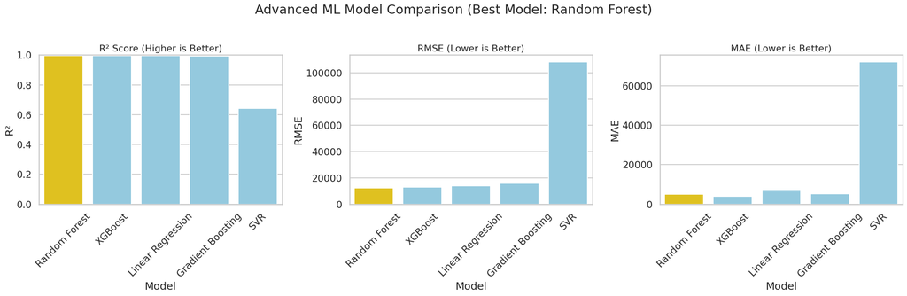

```python
import matplotlib.pyplot as plt
import seaborn as sns

# Advanced styling for Master's level
sns.set(style="whitegrid", context="talk")

# Identify the best model clearly
best_model = results_df.loc[0, 'Model']

# Custom color palettes to highlight the best model
def highlight_palette(model_names, best_model, highlight_color='gold', base_color='skyblue'):
    return [highlight_color if model == best_model else base_color for model in model_names]

# Define subplots clearly
fig, axes = plt.subplots(1, 3, figsize=(22, 7))

# R² Plot with highlighted best model
sns.barplot(
    x='Model', y='R²', data=results_df, ax=axes[0],
    palette=highlight_palette(results_df['Model'], best_model)
)
axes[0].set_title('R² Score (Higher is Better)', fontsize=16)
axes[0].set_ylim(0, 1)
axes[0].tick_params(axis='x', rotation=45)

# RMSE Plot with highlighted best model
sns.barplot(
    x='Model', y='RMSE', data=results_df, ax=axes[1],
    palette=highlight_palette(results_df['Model'], best_model)
)
axes[1].set_title('RMSE (Lower is Better)', fontsize=16)
axes[1].tick_params(axis='x', rotation=45)

# MAE Plot with highlighted best model
sns.barplot(
    x='Model', y='MAE', data=results_df, ax=axes[2],
    palette=highlight_palette(results_df['Model'], best_model)
)
axes[2].set_title('MAE (Lower is Better)', fontsize=16)
axes[2].tick_params(axis='x', rotation=45)

# Master title for clarity
fig.suptitle(f'Advanced ML Model Comparison (Best Model: {best_model})', fontsize=22, y=1.02)

plt.tight_layout()
plt.show()
```

References:

Pedregosa, F., Varoquaux, G., Gramfort, A., Michel, V., Thirion, B., Grisel, O., Blondel, M., Prettenhofer, P., Weiss, R., Dubourg, V., Vanderplas, J., Passos, A., Cournapeau, D., Brucher, M., Perrot, M. and Duchesnay, E. (2011) Scikit-Learn: Machine Learning in Python. Journal of Machine Learning Research, 12, 2825-2830.

Chen, T., & Guestrin, C. (2016). XGBoost: A scalable tree boosting system. Proceedings of the 22nd ACM SIGKDD International Conference on Knowledge Discovery and Data Mining, 785–794. https://doi.org/10.1145/2939672.2939785

Breiman, L. (2001). Random forests. Machine Learning, 45(1), 5–32. https://doi.org/10.1023/A:1010933404324

Cort J. Willmott, Kenji Matsuura Climate Research, Vol. 30, No. 1 (December 19 2005), pp. 79-82 (4 pages)

https://www.jstor.org/stable/24869236